# BIO532 Introduction to R

Michal L Collyer

9/1/2020

# BIO532 R INTRODUCTION, just some basics for using R

First thing to note, if one wants to add notes to an R script one must use a # to type the note. DO THIS OFTEN!!!! IT HELPS OTHERS UNDERSTAND YOUR INTENTION. It also reminds you what you were attempting to do later. Finally, you might have to submit scripts as homework. If you have trouble, it’s easier to communicate what you were attempting to do with annotated scripts.

### Typing in data or data files

```r
a = 4
a
```

```
## [1] 4
```

```r
a <- 4
a
```

```
## [1] 4
```

Note that spaces are not needed. Note that the arrow assigns an object a value, a string of values, or a function. Note that in R, as we will see later, an actual equality might need `==` (two equal signs) to differentiate it from an assignment. Therefore, I recommend using arrows instead of equal sign.

### Other types of assignments

```r
b <- c(4, 2, 5) # c means concatenate or combine
c <- array(1:5)
c <- 1:5
d <- array(1, 10)
e <- array(1:3, 15)
f <- rep(seq(1, 4, 1), 5) # seq means sequence (from 1 to 4 by 1s); rep = repeat (5 times)
g <- c("I", "LOVE","R",4,"STATISTICS")
h <- c("I love R for statistics")

a
```

```
## [1] 4
```

```r
b
```

```
## [1] 4 2 5
```

```r
c
```

```
## [1] 1 2 3 4 5
```

```r
d
```

```
##  [1] 1 1 1 1 1 1 1 1 1 1
```

```r
e
```

```
##  [1] 1 2 3 1 2 3 1 2 3 1 2 3 1 2 3
```

```r
f
```

```
##  [1] 1 2 3 4 1 2 3 4 1 2 3 4 1 2 3 4 1 2 3 4
```

```r
g
```

```
## [1] "I"          "LOVE"       "R"          "4"          "STATISTICS"
```

```r
h
```

```
## [1] "I love R for statistics"
```

If one wants to assign a few variables they can type it all in and assemble a data frame; e.g.,

```r
x = c(10, 11, 14, 15, 9, 12, 8)
y = c(100, 100, 110, 100, 120, 140, 110)
z = factor(c(rep("A", 4),rep("B", 3))) # factor means a nominal/categorical variable

x
```

```
## [1] 10 11 14 15  9 12  8
```

```r
y
```

```
## [1] 100 100 110 100 120 140 110
```

```r
z
```

```
## [1] A A A A B B B
## Levels: A B
```

```r
Y = data.frame(x,y,z)
Y # each row is a subject with three values for three variables/variates
```

```
##    x   y z
## 1 10 100 A
## 2 11 100 A
## 3 14 110 A
## 4 15 100 A
## 5  9 120 B
## 6 12 140 B
## 7  8 110 B
```

Data Frames are the most common way to deal with data for statistical analysis. They are matrices, but with the specific designation that columns are variables

### Reading in files

One will do this a lot, if one has data, say, in an Excel file or other type of spreadsheet. IT IS BEST TO SAVE EXCEL FILES AS TEXT DOCUMENTS. FOR EXAMPLE, “save as”, THEN CHOOSE .csv or .txt. There are different formats to use, but .csv (comma separated values) files work regularly and do not require knowing the difference between a space and a tab (values in text files can be separated or ‘delimited’ by commas, spaces, or tabs). **At this point, please download the CSV file, lowbwt.csv, from Brightspace/Resources/Data Files.** Make sure you know the location of the file on your computer. lowbwt.csv is a set of data for babies born with low birthweight (from Pagano and Gauvreau, Biostatistics, 1992).

The simple way (if you like clicking buttons):

- Look over to the upper-right of R-Studio,
- Click on “Environment” tab, then “Import Dataset”.
- Should be sort of obvious what to do…

The purer way (if you like command line text)”

- First, change the directory in R to match that directory
- (Session/Set Working Directory/Choose Location)
  - Go to the “Session” pull-down menu
  - Go to “Set Working Directory”
  - Find the directory where the spreadsheet is saved.

```r
# lowbwt = read.csv("low.bwt.csv",header=T) Remove the # when you do this for real...
```

Look at the data in the environment tab (click on it in the environment tab - opens a spreadsheet). Or just do this:

```r
lowbwt
```

```
##     sbp sex tox grmhem gestage apgar5
## 1    43   1   0      0      29      7
## 2    51   1   0      0      31      8
## 3    42   0   0      0      33      0
## 4    39   0   0      0      31      8
## 5    48   0   1      0      30      7
## 6    31   1   0      1      25      0
## 7    31   1   1      0      27      7
## 8    40   0   0      0      29      9
## 9    57   0   0      0      28      6
## 10   64   0   1      0      29      9
## 11   46   0   0      0      26      7
## 12   47   0   0      1      30      6
## 13   63   0   0      0      29      8
## 14   56   0   0      0      29      1
```

[output cut: 86 more lines]

or this:

```r
View(lowbwt)
```

No matter how the data were opened, look at the console. `read.csv` is a function. It performs a task. If you ever need help using a function use `?` followed by the function; e.g.,

```r
? read.csv
? factor
? seq
```

Note that any spreadsheet in Excel can be saved as a text file. One must do this to read the file into R. Other stats programs might be able to read Excel files. There used to be a package for doing this in R but I believe it had trouble keeping up with Microsoft updates. Using ext files is universal. JUST MAKE TEXT FILES! Saves some headaches.

### Playing with the data

```r
dim(lowbwt) # provides the dimensions of the "data frame"
```

```
## [1] 100   6
```

```r
str(lowbwt) # an overview of the structure of the object, lowbwt
```

```
## 'data.frame':    100 obs. of  6 variables:
##  $ sbp    : int  43 51 42 39 48 31 31 40 57 64 ...
##  $ sex    : int  1 1 0 0 0 1 1 0 0 0 ...
##  $ tox    : int  0 0 0 0 1 0 1 0 0 1 ...
##  $ grmhem : int  0 0 0 0 0 1 0 0 0 0 ...
##  $ gestage: int  29 31 33 31 30 25 27 29 28 29 ...
##  $ apgar5 : int  7 8 0 8 7 0 7 9 6 9 ...
```

```r
lowbwt[33,2] # provides the value in the 33rd row and 2nd column
```

```
## [1] 0
```

```r
lowbwt[33,] # provides the entire 33rd row
```

```
##    sbp sex tox grmhem gestage apgar5
## 33  35   0   0      0      31      6
```

```r
lowbwt[,2] # provides the entire 2nd column
```

```
##   [1] 1 1 0 0 0 1 1 0 0 0 0 0 0 0 1 1 0 0 0 0 1 0 1 1 0 1 0 1 0 0 1 0 0 1 0 0 1
##  [38] 0 1 0 1 1 1 0 0 0 1 1 0 0 0 1 1 1 0 1 0 0 0 0 1 0 1 1 0 0 0 0 0 0 1 1 0 0
##  [75] 1 1 1 0 0 0 0 0 0 0 1 1 1 1 1 1 1 1 0 1 1 0 1 1 0 0
```

```r
lowbwt[1:10,] # provides the first 10 rows
```

```
##    sbp sex tox grmhem gestage apgar5
## 1   43   1   0      0      29      7
## 2   51   1   0      0      31      8
## 3   42   0   0      0      33      0
## 4   39   0   0      0      31      8
## 5   48   0   1      0      30      7
## 6   31   1   0      1      25      0
## 7   31   1   1      0      27      7
## 8   40   0   0      0      29      9
## 9   57   0   0      0      28      6
## 10  64   0   1      0      29      9
```

```r
lowbwt[-(3:20),] # provides the entire data frame, minus the third through twentieth rows
```

```
##     sbp sex tox grmhem gestage apgar5
## 1    43   1   0      0      29      7
## 2    51   1   0      0      31      8
## 21   51   1   0      0      28      7
## 22   47   0   0      0      30      9
## 23   54   1   0      0      27      4
## 24   64   1   0      0      33      9
## 25   37   0   0      0      32      7
## 26   36   1   1      0      28      3
## 27   45   0   0      1      29      7
## 28   39   1   0      0      28      7
## 29   29   0   0      0      29      4
## 30   61   0   0      0      30      3
## 31   53   1   0      0      31      7
## 32   64   0   0      0      30      7
```

[output cut: 68 more lines]

When objects have “sublevels”, the symbol,‘$’,is used to strictly pay attention to a sublevel; e.g.,

```r
str(lowbwt)
```

```
## 'data.frame':    100 obs. of  6 variables:
##  $ sbp    : int  43 51 42 39 48 31 31 40 57 64 ...
##  $ sex    : int  1 1 0 0 0 1 1 0 0 0 ...
##  $ tox    : int  0 0 0 0 1 0 1 0 0 1 ...
##  $ grmhem : int  0 0 0 0 0 1 0 0 0 0 ...
##  $ gestage: int  29 31 33 31 30 25 27 29 28 29 ...
##  $ apgar5 : int  7 8 0 8 7 0 7 9 6 9 ...
```

Make certain variables are turned into factors

```r
lowbwt$sex <- factor(lowbwt$sex)
lowbwt$tox <- factor(lowbwt$tox)
lowbwt$grmhem <- factor(lowbwt$grmhem)

str(lowbwt)
```

```
## 'data.frame':    100 obs. of  6 variables:
##  $ sbp    : int  43 51 42 39 48 31 31 40 57 64 ...
##  $ sex    : Factor w/ 2 levels "0","1": 2 2 1 1 1 2 2 1 1 1 ...
##  $ tox    : Factor w/ 2 levels "0","1": 1 1 1 1 2 1 2 1 1 2 ...
##  $ grmhem : Factor w/ 2 levels "0","1": 1 1 1 1 1 2 1 1 1 1 ...
##  $ gestage: int  29 31 33 31 30 25 27 29 28 29 ...
##  $ apgar5 : int  7 8 0 8 7 0 7 9 6 9 ...
```

```r
lowbwt$sbp
```

```
##   [1] 43 51 42 39 48 31 31 40 57 64 46 47 63 56 49 87 46 66 42 52 51 47 54 64 37
##  [26] 36 45 39 29 61 53 64 35 34 62 59 36 47 45 62 75 44 39 48 43 19 63 42 44 25
##  [51] 26 27 35 40 44 66 59 24 40 49 53 45 50 64 48 48 58 67 40 48 36 44 53 45 54
##  [76] 44 42 50 48 29 30 36 44 46 51 51 43 48 52 43 42 48 49 62 45 51 52 47 40 50
```

```r
lowbwt$apgar5
```

```
##   [1] 7 8 0 8 7 0 7 9 6 9 7 6 8 1 8 7 8 8 8 7 7 9 4 9 7 3 7 7 4 3 7 7 6 9 7 8 9
##  [38] 8 2 5 7 0 8 7 6 4 7 6 9 8 8 9 8 7 6 8 3 7 3 5 9 9 8 7 6 4 7 8 8 8 5 6 9 6
##  [75] 8 2 5 0 5 5 2 0 0 9 4 5 7 5 8 6 8 5 8 7 9 6 8 5 8 7
```

### COMMON SUMMARY FUNCTIONS

- summary, mean, median, quantile, min, max, var, sd, IQR,
- plot (generic), barplot, boxplot, hist, rug, table

Remember, for R, a qualitative variable is a “factor”; quantitative variables can be integer (discrete) or numeric (continuous)

### Quick summaries

```r
summary(lowbwt)
```

```
##       sbp        sex    tox    grmhem    gestage          apgar5
##  Min.   :19.00   0:56   0:79   0:85   Min.   :23.00   Min.   :0.00
##  1st Qu.:40.00   1:44   1:21   1:15   1st Qu.:27.00   1st Qu.:5.00
##  Median :47.00                        Median :29.00   Median :7.00
##  Mean   :47.08                        Mean   :28.89   Mean   :6.25
##  3rd Qu.:52.25                        3rd Qu.:31.00   3rd Qu.:8.00
##  Max.   :87.00                        Max.   :35.00   Max.   :9.00
```

Quartiles… (Note difference between quantile and quartile)

```r
quantile(lowbwt$sbp, c(0.25, 0.50, 0.75)) # Quartiles are quantiles; not the other way around
```

```
##   25%   50%   75%
## 40.00 47.00 52.25
```

```r
quantile(lowbwt$sbp, 0.37) # 37th percentile (quantiles also called percentiles)
```

```
## 37%
##  44
```

### Histogram

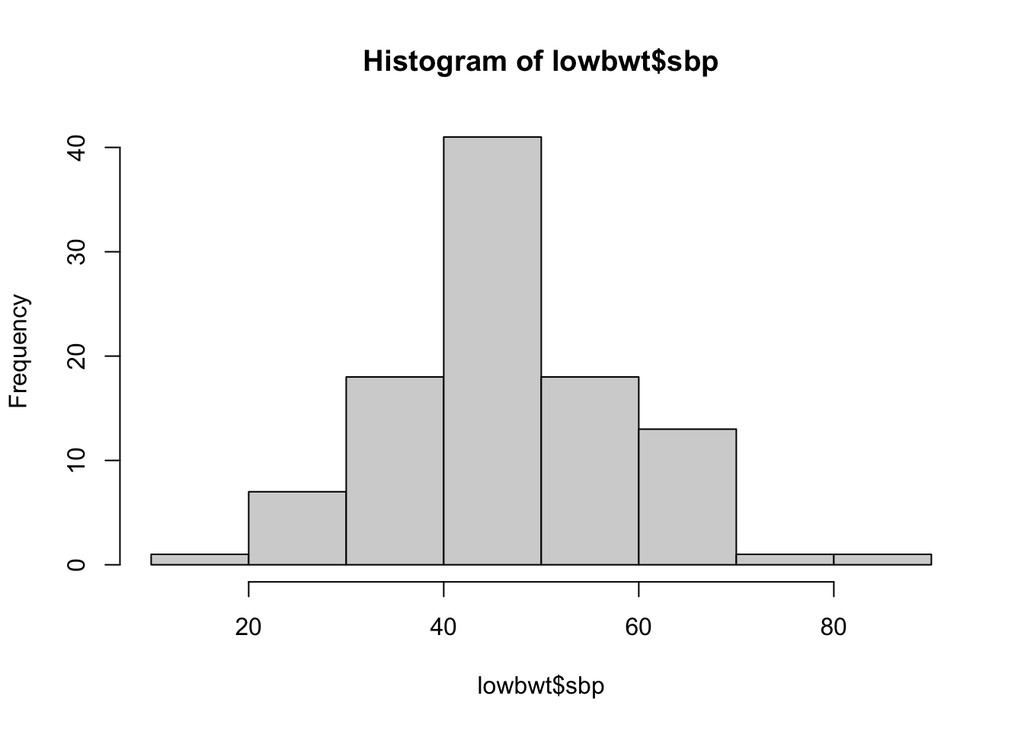

```r
hist(lowbwt$sbp)
```

Need some help?

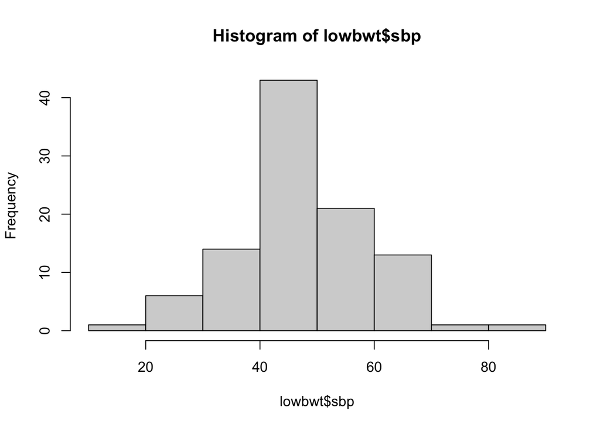

```r
?hist

hist(lowbwt$sbp, right = FALSE,
     breaks = c(10, 20, 30, 40, 50, 60, 70, 80, 90))
```

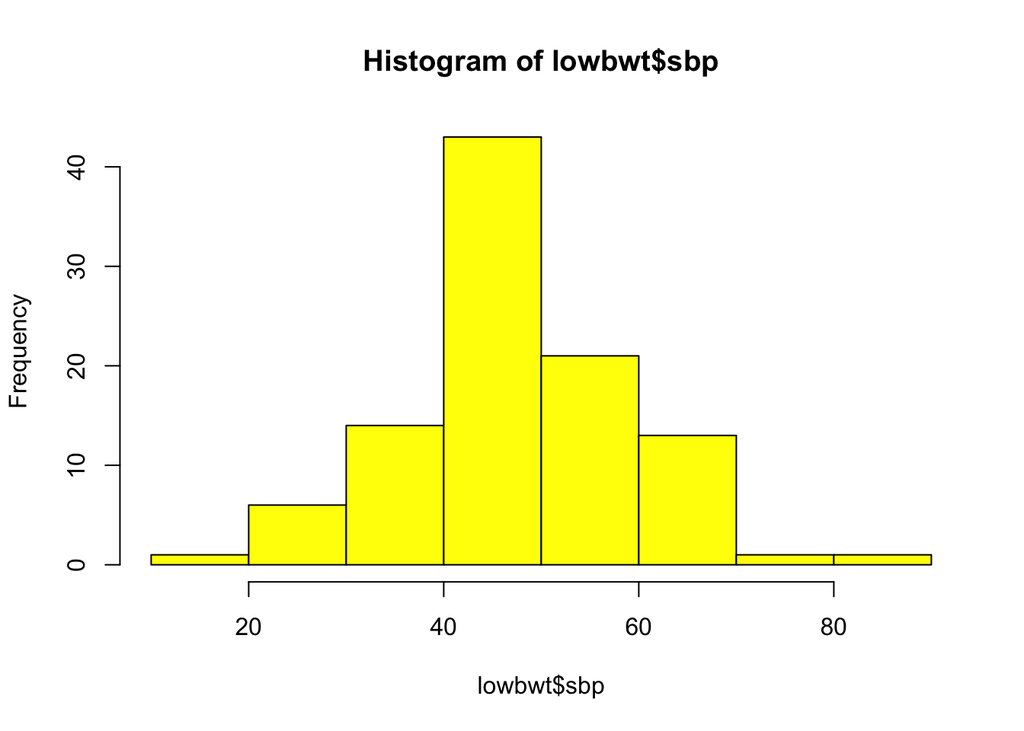

```r
# let's get fancier...

hist(lowbwt$sbp, right = FALSE,
     breaks = c(10, 20, 30, 40, 50, 60, 70, 80, 90),
     col = "yellow")
```

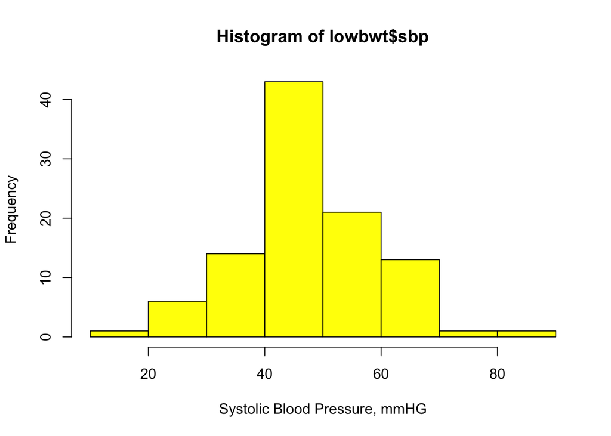

```r
hist(lowbwt$sbp, right = FALSE,
     breaks = c(10, 20, 30, 40, 50, 60, 70, 80, 90),
     col = "yellow",
     xlab = "Systolic Blood Pressure, mmHG",
     ylab = "Frequency")
```

### More plots

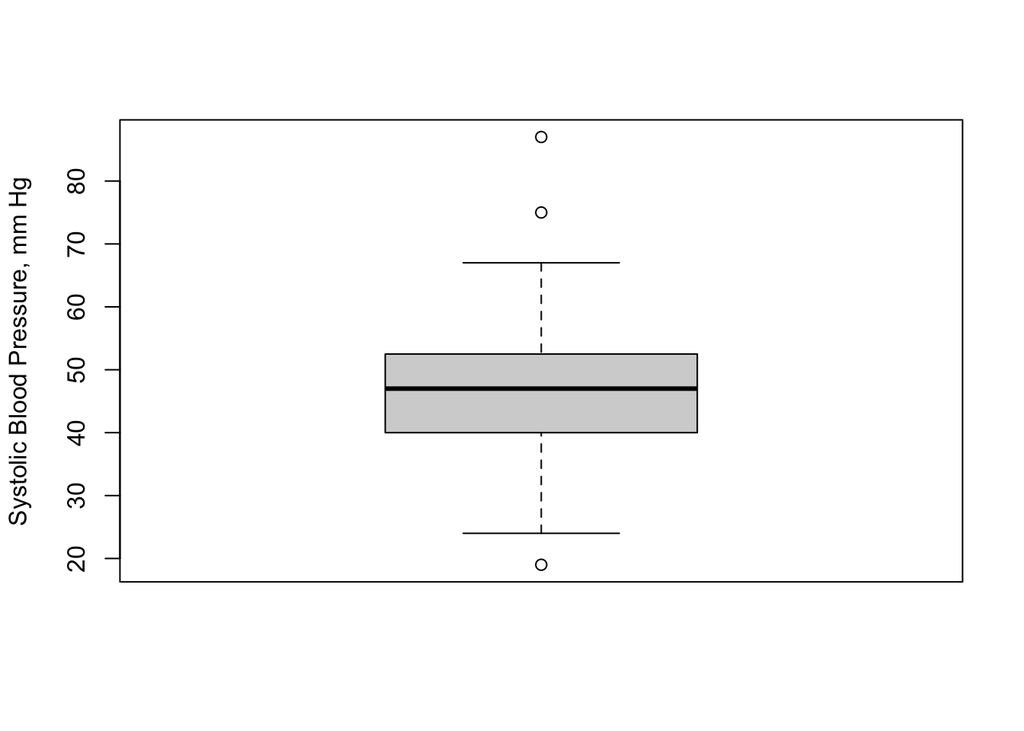

```r
boxplot(lowbwt$sbp, ylab = "Systolic Blood Pressure, mm Hg")
```

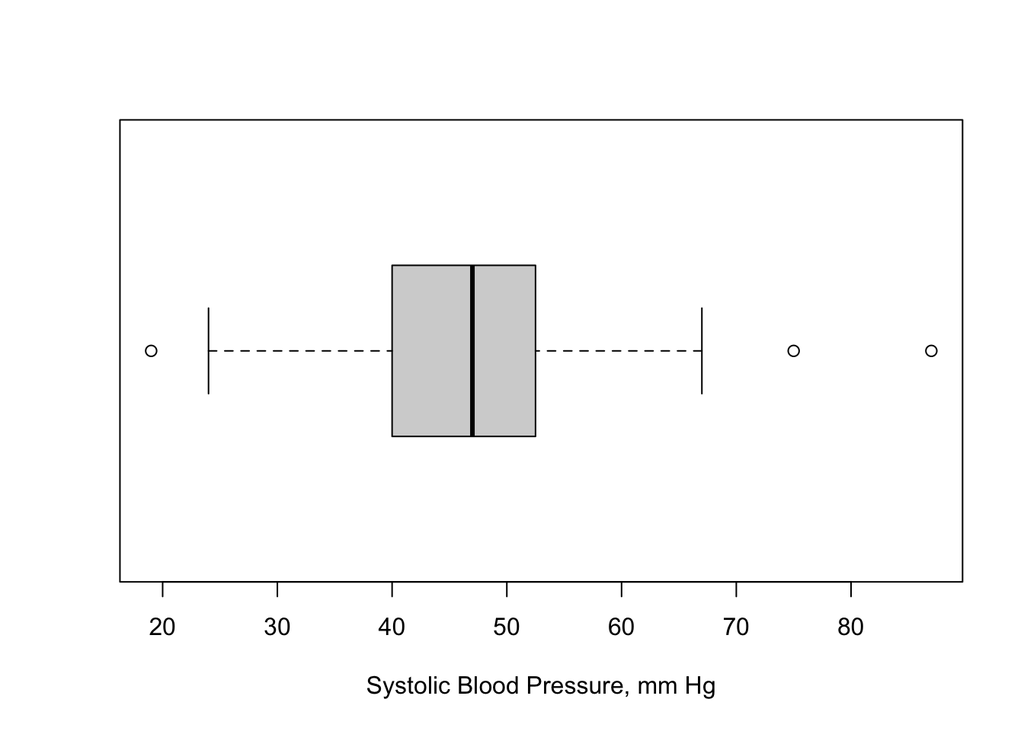

```r
boxplot(lowbwt$sbp, horizontal = TRUE,
        xlab = "Systolic Blood Pressure, mm Hg")
```

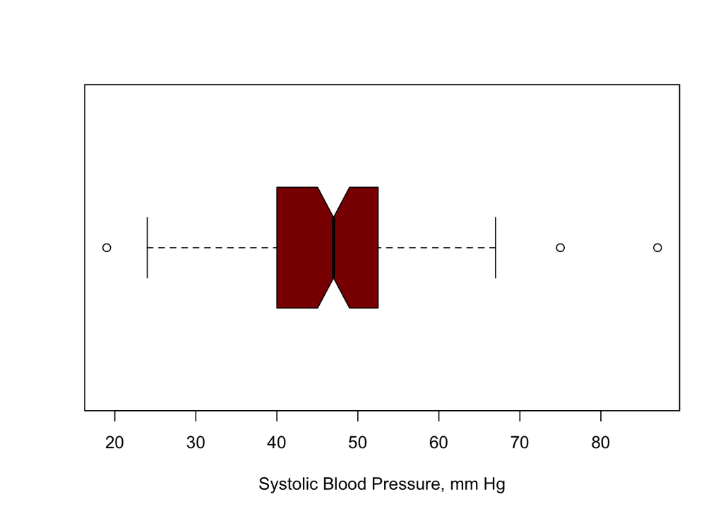

```r
boxplot(lowbwt$sbp, horizontal = TRUE,
        xlab = "Systolic Blood Pressure, mm Hg",
        notch = TRUE,
        col = "dark red")
```

```r
?boxplot # If help is needed
```

### Dispersion

```r
var(lowbwt$sbp) # sample variance
```

```
## [1] 130.0339
```

```r
sd(lowbwt$sbp) # sample SD
```

```
## [1] 11.40324
```

```r
IQR(lowbwt$sbp)
```

```
## [1] 12.25
```

# Summary

There are so many things we can do with R but it can also be overwhelming. Future exercises will introduce new functions to use. Do not worry about how much you understand right now. Here are some goals for this session:

1. Be able to read in data frames
2. Understand what a function is/does; e.g., var( )
3. Understand how to find help; e.g., ? var
4. Get comfortable moving around in R Studio